# Analyzing relations of prison population, location, and social identity

Hannah Wee

2022-11-21

## Abstract

My main concern is the correlation between prison population by identity, intersectionality, and system of oppression. My question is how does social identities, specifically gender, affect inequality patterns of prisoner population? To address this question, I analyzed data sets in different social identities and filtered location and gender information about prison population to visualize the datasets.

## Introduction

As mentioned in *Data Feminism*, Data feminists should not only be aware of the inequality in the world but also act to improve the inequality in our world. By examining and visualizing the prison data sets, I hope to find evidence of apparent inequality patterns in our society. Racism and sexism are still apparent in our society so through visualizing and organizing raw data sets, I hope it can convey values of activism and action towards direct stakeholders, sociologists or government officials, and indirect stakeholders, viewers, or audience of visualization, to make the world a more inviting place for all identities. The inequalities portrayed through visualization serve as a purpose to not only support evidence that there are inequalities in our society to viewers but also bring change to the inequality by impacting the government officials who are in charge of making and editing laws of society. As a data feminist mindset, the goal is to make an impact on dissolving apparent inequalities using data which is what this project is aimed to do.

## Data Summary

### Growth of US Prison Population

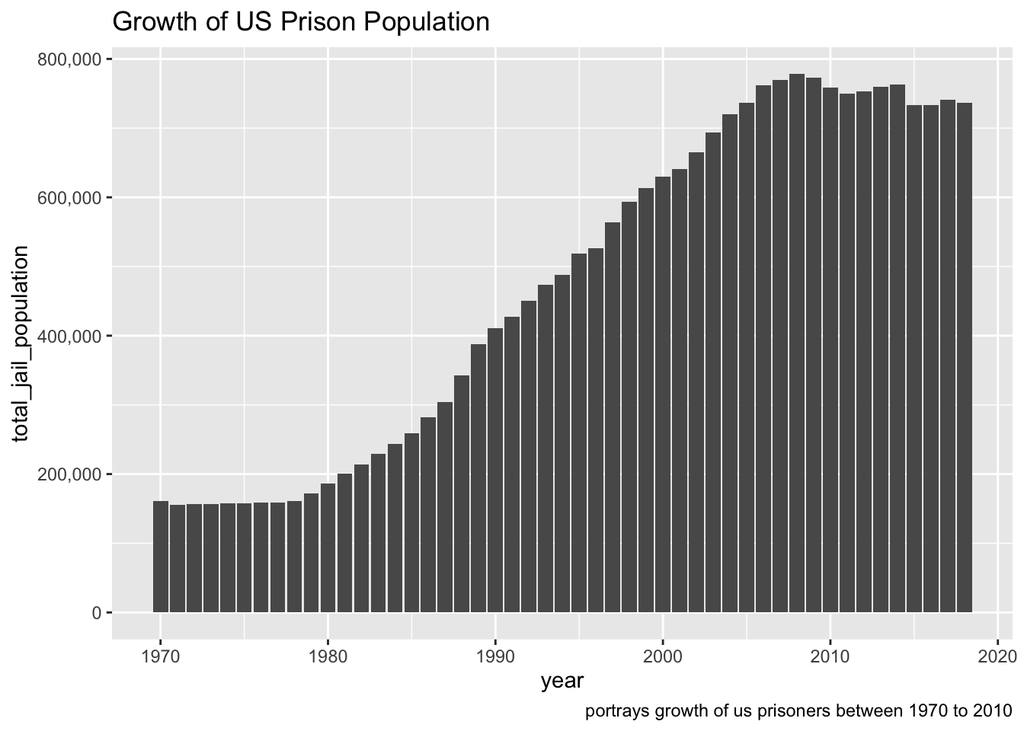

### Growth of US Prison Population by State

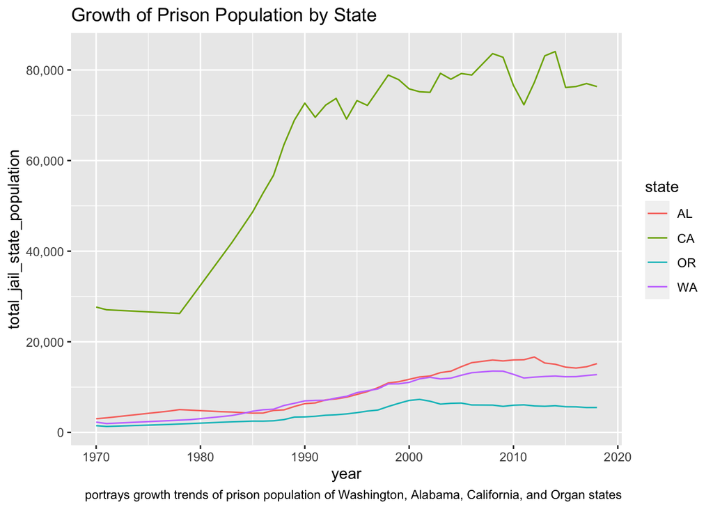

### Growth of US Prison Population by Gender

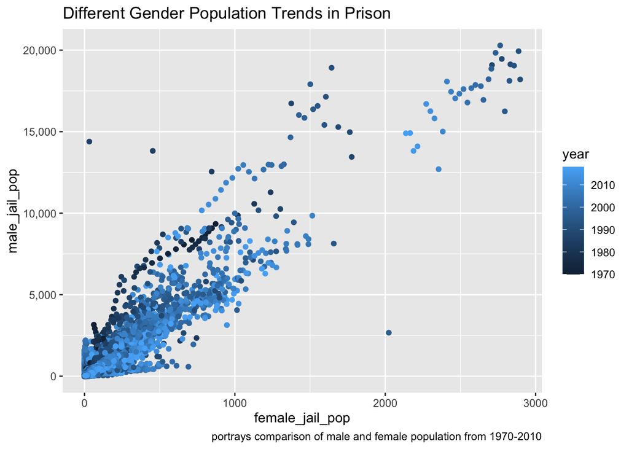

The scatter plot is specifically chosen to answer the question of is there are inequality pattern of prisoners among gender? There seems to be an overall positive correlation of female and male population but looking at the scales for male and female jail population, it can be seen that there are more male jail population than female jail population. The color scheme also shows the year of when population was recorded and it shows that there are diverse amounts of population of both genders throughout the year progressed. The scale for male jail population is 20,000 but female jail population is only 3,000 max which indicates a pattern of inequality in terms of there are more male prisoners than female prisoners by a huge difference.

### Total population of female prison by state

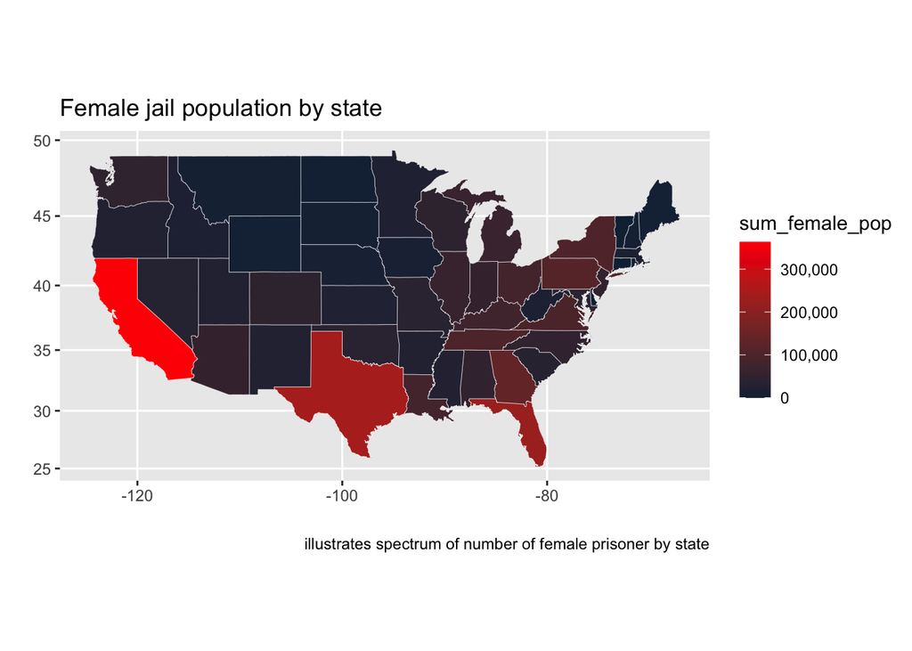

### Total population of male prison by states

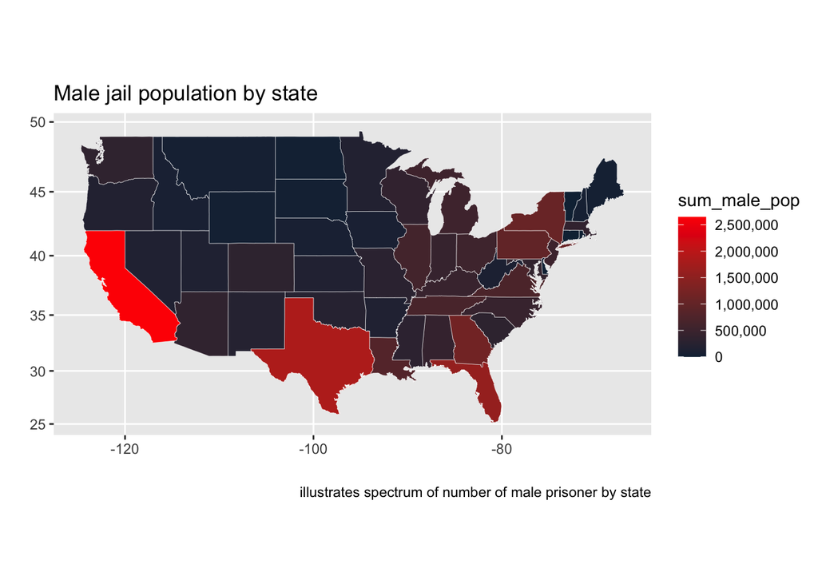

The map answer the question: are there inequality between binary genders, male and female, of becoming prisoners? The male population scale shows a higher maximum number than female population by around 2,200,000 people, which is overall overwhelmingly different from number of women prisoners. The location overall stayed the same for number of prisoners per state for both gender by having north middle part of US with lowest and south states like Californian or Texas having the highest, but the recorded values for prisoners shows the huge difference between binary genders, proving that our society have more male prisoners than female prisoners.

*All the very best with your work!*